# Analysis of Variance

What do you mean variation helps us compare means?

P. Lombardo

## Loading packages, etc.

```r
library(tidyverse)
library(patchwork)
library(DescTools)
library(broom)
source("source_files/HT_errors_ANOVA.R")

fish<-read.csv('data/fish.csv', header = T,
               stringsAsFactors = T)


get_name<-function(i){
    nm<-c("May","Jun","Jul","Aug","Sep")
    nm[i-4]
}
airquality<-airquality %>% mutate(
    MonthName = factor(sapply(airquality$Month,get_name),
                       levels = c("May","Jun","Jul","Aug","Sep"))
)
```

## Comparing Means of Many Populations

### Warm up

Let’s consider our “Type I Error” situation from the previous lesson:

- We create 10 different samples of size 30 from a standard normal distribution. In other words, *all 10 samples were drawn from populations with an equal mean!* (That population mean is zero.)
- Let’s test the null hypothesis
  $$H_0:
  \mu_1 = \mu_2 = ... =\mu_{10}$$
  Using an ANOVA, rather than pairwise testing.
  - The Type I Error rate here for an ANOVA should be the same as our significance level, since it protects against Type I Error inflation.

```r
# Can you understand what the code below does?
# set.seed(744) # no type I errors
set.seed(732) # one type I errors
samples_df<-data.frame(
    measurements=rnorm(10*30),
    sample_num=rep(paste("Samp",1:10,sep=""),30)
)
```

**Exercise.** Create a summary table that compares the means, medians, standard deviations, and IQRs for each of the ten samples.

```r
# place code here
samples_df %>% head()
```

|  | measurements | sample_num |
| --- | --- | --- |
| 1 | -0.0315023 | Samp1 |
| 2 | 2.1390857 | Samp2 |
| 3 | -0.8050211 | Samp3 |
| 4 | -0.8722862 | Samp4 |
| 5 | 1.5316045 | Samp5 |
| 6 | -0.1009705 | Samp6 |

```r
samples_df %>%
    group_by(sample_num) %>%
    summarise(
        mean = mean(measurements),
        median = median(measurements),
        stdev = sd(measurements),
        IQR = IQR(measurements),
        sample_size = n()
    )
```

| sample_num | mean | median | stdev | IQR | sample_size |
| --- | --- | --- | --- | --- | --- |
| Samp1 | -0.06256004 | -0.0245568754 | 0.9476548 | 1.0630680 | 30 |
| Samp10 | 0.15933099 | 0.1582117649 | 1.1686113 | 1.4128609 | 30 |
| Samp2 | 0.16043738 | 0.0667431531 | 0.8810977 | 1.1686124 | 30 |
| Samp3 | 0.12286321 | -0.0381221669 | 0.9265634 | 1.0334201 | 30 |
| Samp4 | 0.05147567 | 0.2295630808 | 0.8577417 | 1.1625532 | 30 |
| Samp5 | -0.09521422 | 0.1594530018 | 1.1552402 | 1.1615861 | 30 |
| Samp6 | -0.05962270 | -0.0006420523 | 1.0563256 | 0.8097157 | 30 |
| Samp7 | 0.43845878 | 0.4644453669 | 1.0518266 | 1.5512672 | 30 |
| Samp8 | 0.04658404 | -0.0060882036 | 1.1637846 | 1.6051232 | 30 |
| Samp9 | 0.02416686 | 0.0702933618 | 0.6915702 | 0.8933962 | 30 |

**Exercise.** Create a comparative boxplot for these ten samples.

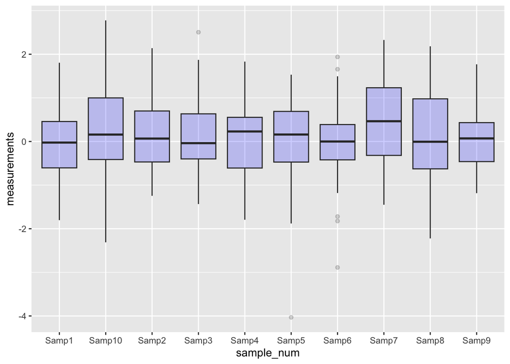

```r
#place code here.
ggplot(data = samples_df,
       aes(x = sample_num, y = measurements))+
    geom_boxplot(fill = 'blue', alpha = .2)
```

**Bonus Demonstration.** That’s right folks, we can create plots from summarized data. First, describe what the code below does!

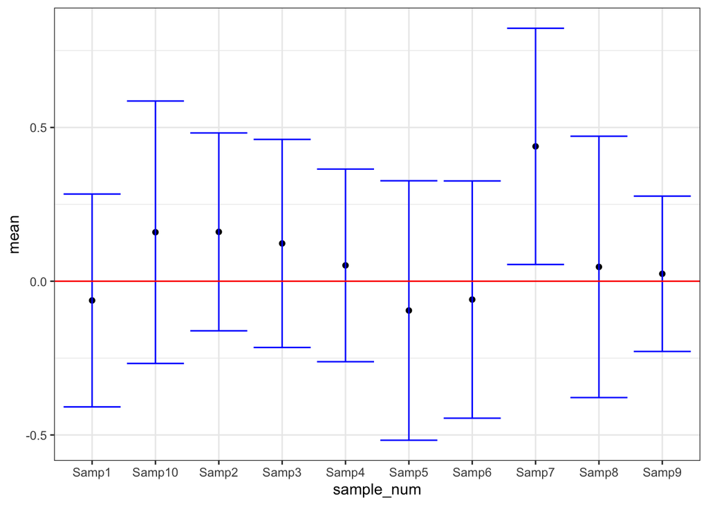

```r
samples_df %>%
    group_by(sample_num) %>%
    summarise(mean = mean(measurements),
              std.error = sd(measurements)/sqrt(30)) %>%
    mutate(low = mean -2*std.error,
           high = mean+2*std.error)  %>%
# Now let's create a plot that adds geom_errorbar() to
# help us visualize the confidence intervals we generated above.
    ggplot(data = .,
           aes(x = sample_num, y = mean))+
    geom_point()+
    geom_errorbar(aes(ymin = low, ymax = high),color='blue')+
    geom_hline(yintercept = 0, color='red')+
    theme_bw()
```

OK, so how do we run an ANOVA? We start by “fitting” that ANOVA with the `aov()` function, and that we summarize it with `summary()`. (Don’t worry about the language, just get used to it.)

```r
# "Fit" the anova using `aov()`
fit1<-aov(measurements~sample_num,
          data = samples_df)
summary(fit1)
```

```
##              Df Sum Sq Mean Sq F value Pr(>F)
## sample_num    9   6.56  0.7288   0.727  0.684
## Residuals   290 290.69  1.0024
```

```r
# or
tidy(fit1) %>% select(p.value)
```

| p.value |
| --- |
| 0.6839961 |
| NA |

While the theory is *really interesting*, we unfortunately don’t have time to discuss it this semester. Alas, you’ll have to make your peace with, temporarily at least, ignoring most of this output and looking straight to the $P$-value for the ANOVA.

**Exercise.** What can we conclude given the $P$-value of this particular exercise? *Be very specific!*

The $P$-value for this hypothesis test (ANOVA) is 0.684, which is well above a significance level of 0.05. We fail to reject the claim that the population means for these ten samples are all equal.

(*Note*: This is the “correct” answer based on our secret knowledge that they were all drawn from a populations with the same mean of 0. No mistake made!)

**Exercise.** Can we get to the $P$-value in one big dplyr pipe? Sure!

```r
# place code here
samples_df %>%
    aov(measurements~ sample_num, data =.) %>%
    tidy() %>% select(p.value)
```

| p.value |
| --- |
| 0.6839961 |
| NA |

## ANOVA Applied Example 1: Tuna weights in Kg.

Let’s explore our first ANOVA example using the `fish` data set. Explore this data frame and answer the questions below:

1. *How many “levels” (or categories) does the categorical variable have? What are the levels?*
2. *Make a boxplot comparing weights of the tuna by species.*
3. *Run an ANOVA to test for a difference in the mean weights of the different species of Tuna.*

What are the levels of `species`?

```r
#place code here
levels(fish$species)
```

```
## [1] "albacore"  "bigeye"    "tongol"    "yellowfin"
```

Let’s look at a boxplot of `weights` by `species`:

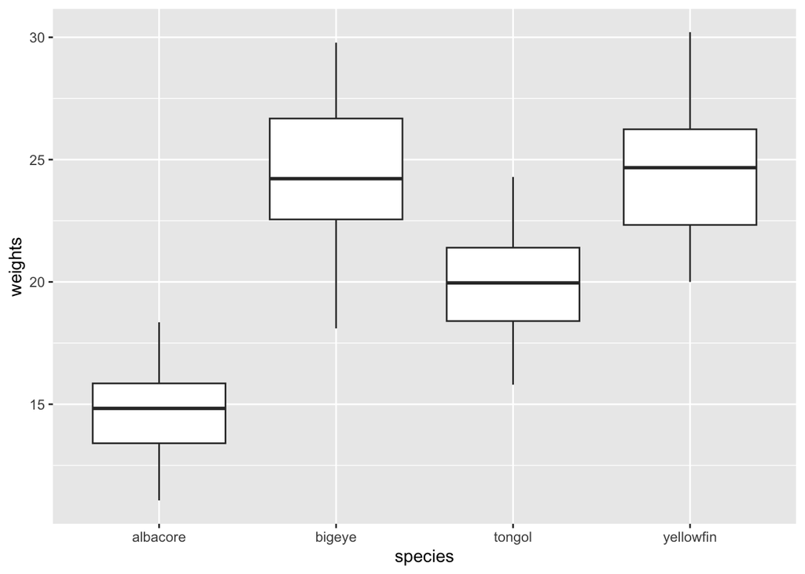

```r
#place code here.
ggplot(data = fish,
       aes(x = species, y = weights))+
    geom_boxplot()
```

**Assumptions for an ANOVA**

For a typical ANOVA, we want to make sure we have the following assumptions met:

1. Samples sizes above 30 *in each group*, *or* we can assume normal population level measurements.
2. About equal standard deviations (three-fold rule).

(*Note:* these are the same as our difference in means confidence interval and hypothesis test. You can think of these as the assumptions that govern all “comparing means” tests.)

*Do we satisfy our assumptions above?*

```r
fish %>%
    group_by(species) %>%
    summarise(
        stdev = sd(weights),
        sample_size = n()
    )
```

| species | stdev | sample_size |
| --- | --- | --- |
| albacore | 1.916580 | 26 |
| bigeye | 2.871684 | 43 |
| tongol | 1.956735 | 37 |
| yellowfin | 2.781986 | 33 |

- The standard deviations follow the three-fold rule (the smallest stdev is about 1.9, and all others are below 3*1.9 =5.7).
- The samples sizes are fine, except for albacore. However, fish weights within species can safely be assumed to have a pretty normal shape.

Good to go!

Lastly, let’s run the ANOVA (We will discuss assumptions in the next section.)

```r
#place code here
# Fit the model
fish %>%
    aov(weights ~ species, data = .) %>%
    tidy() %>% select(p.value)
```

| p.value |
| --- |
| 4.860902e-35 |
| NA |

Follow up questions:

2. *What is the P-value of this ANOVA?*

The $P$-value is 0.0000…. 34 zeroes later…486. It’s extremely small, and certainly less than any reasonable significance level, but we’ll use 0.05.

3. *What can we conclude from the results?*

At least one species of tuna has a different population mean than the others. (We can’t make specific conclusions about individual comparisons; we don’t even know which species is different or if there are several species that are different!)

#### Example: `airquality`

The `airquality` data frame consists of air quality measurements from areas near New York City from May 1973 to September 1973.

As researchers, we believe that the `Ozone` measurements are influenced by the Month of the year; specifically, we suspect that the mean Ozone levels will be different depending on the Month. *Our Null hypothesis, then, will be that the mean ozone levels are equal across the months of May through September.*

1. What kind of statistical test is best for testing this null hypothesis, and why?

```r
unique(airquality$MonthName)
```

```
## [1] May Jun Jul Aug Sep
## Levels: May Jun Jul Aug Sep
```

We need to use ANOVA *because* we have more than 2 months (or more than 2 categories) that we need to consider when comparing means.

2. Create a boxplot of the `Ozone` measurements broken up by `MonthName`.

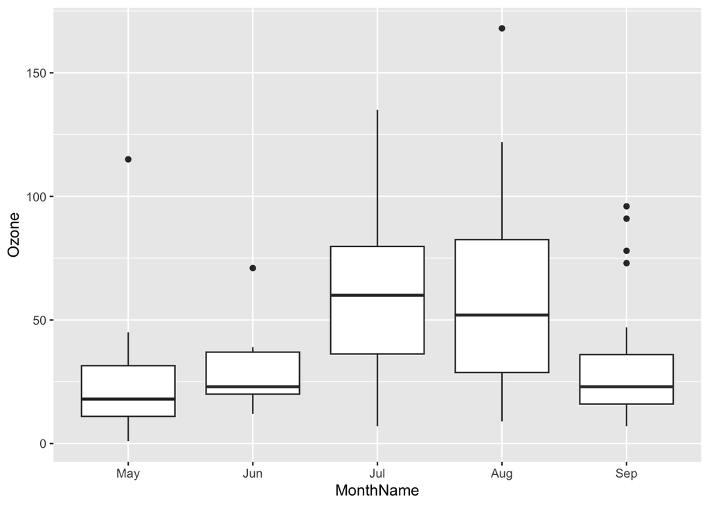

```r
#place code here
airquality %>%
    filter(!is.na(Ozone)) %>%
ggplot(data =.,
       aes(x= MonthName, y = Ozone))+
    geom_boxplot()
```

```r
airquality %>%
    filter(!is.na(Ozone)) -> ozone1
```

3. What are the sample mean `Ozone` levels broken up by `MonthName`? What about the sample standard deviations in each for each month?

```r
#place code here.
ozone1 %>%
    group_by(MonthName) %>%
    summarise(
        mean = mean(Ozone),
        stdev = sd(Ozone),
        sample_size = n()
    )
```

| MonthName | mean | stdev | sample_size |
| --- | --- | --- | --- |
| May | 23.61538 | 22.22445 | 26 |
| Jun | 29.44444 | 18.20790 | 9 |
| Jul | 59.11538 | 31.63584 | 26 |
| Aug | 59.96154 | 39.68121 | 26 |
| Sep | 31.44828 | 24.14182 | 29 |

4. Fit an ANOVA and summarize it to get the $P$-value for this hypothesis test.

```r
#Place code here
ozone1 %>%
    aov(Ozone~MonthName, data = .) %>%
    tidy() %>% select(p.value)
```

| p.value |
| --- |
| 4.827065e-06 |
| NA |

5. What is our conclusion?

Since our $P$-value (0.00000483) is below a significance level of 0.05, we have evidence to reject the claim that the mean Ozone levels are equal across all the summer months.

## Assumptions for an ANOVA

For a typical ANOVA, we want to make sure we have the following assumptions met:

1. Samples sizes above 30 *in each group*, *or* we can assume normal population level measurements.
2. About equal standard deviations (three-fold rule).

(*Note:* these are the same as our difference in means confidence interval and hypothesis test. You can think of these as the assumptions that govern all “comparing means” tests.)

*Did we satisfy our assumptions above?*

Well, the variation was fine (lowest was about 18 with the largest being 40); we follow the three-fold rule

Our sample sizes were *all* under 30, so can we assume the Ozone levels have normal shape within each month?

- Personally, I don’t know if that assumption is a safe one. So I would probably not trust this ANOVA.
- What’s at stake? Without satisfying the assumptions of the test, the Type I and type II error rates will not be what we expect them to be. So we may be more likely to commit one of these mistakes if we trust the hypothesis test.

## Post-hoc testing with Tukey’s HSD:

### How does it work? (Optional)

Using an ANOVA, we can determine whether there is evidence that **at least one** group mean is significantly different than the others. However, it does not tell us *which* mean (or means) are different! For that, we need “post-hoc” testing.

**Basic idea:** go back to pair-wise testing!

The only way to tease out differences is to look at comparisons of each group mean pair-wise. But as we mentioned Wednesday, this leads to higher type I error rates! What can we do?

If using a 5% significance level for the pair-wise comparisons leads to a large overall type I error rate, why don’t we use a smaller significance level on the pair-wise comparisons to *lower* the overall type I error rate?

Suppose you have $m$ different pair-wise comparisons to make. The *Bonferroni correction* essentially says to use $\alpha/m$ as your *pair-wise significance level*, and this will keep the type I error rate for the *group test* around $\alpha$.

- For example, suppose I’m looking for differences in means for 10 different populations, and I want to keep my Type I Error rate at 5%.
  - Comparing 10 populations pair-wise would involved 45 two-sample tests.
  - **The Bonferroni correction would tell me to do pair-wise comparisons, but use $0.05/45 \approx 0.001111$ as my significance value for each test.**

Let’s consider our simulation from Wednesday’s class where we simulated testing equal means for 10 populations; this required 45 pair-wise comparisons. (Remember we set up the code so that $H0: \mu_1 = ... =\mu_{10}$ is true, so this will estimate the type I error.)

- Run the code once to re-affirm that pair-wise testing leads to inflated type I error risk.
- Now update the code below (in line 178) so that we use a significance level of $0.05/45$ *on the pair-wise tests* (or `block45` $P$-values). What happens?

```r
reject_Big_H0<-logical(200)
for (i in 1:200){
    # This code runs a block of 45 tests and
    # collects P-values
    block45<-sapply(1:45,two_sample_get_p)

    # Store TRUE/FALSE based on *at least one* pval under 0.05
    # We will adjust the code below for Bonferroni's correction


    ###########################
    ## UPDATE REQUIRED!!!######
    ###########################

    reject_Big_H0[i]<- sum(block45<0.05/45) >= 1  # <---- UPDATE THIS LINE, change 0.05 to   0.05/45 to make a "bonferroni" correction.


}

sum(reject_Big_H0)/200
```

```
## [1] 0.05
```

### Tukey’s HSD

A common post-hoc test is the Tukey’s Honest Significant Difference Test. (This has many names, including Tukey-Kramer test, Tukey’s Range test, etc.) In `R`, we can run this test by passing the fitted analysis of variance model into the `TukeyHSD()` command. Let’s try it on our `fish` ANOVA from above:

```r
# Place code here.
fish %>%
    aov(weights~species, data = .) %>%
    TukeyHSD() %>% tidy() %>%
    select(contrast, adj.p.value)
```

| contrast | adj.p.value |
| --- | --- |
| bigeye-albacore | 0.000000e+00 |
| tongol-albacore | 2.496336e-12 |
| yellowfin-albacore | 0.000000e+00 |
| tongol-bigeye | 1.159628e-12 |
| yellowfin-bigeye | 9.999035e-01 |
| yellowfin-tongol | 1.390787e-11 |

*For each pair of groups, we compute an “adjusted $P$-value” that we can compare against our original significance level to see if there is evidence for a difference between these pairs.*

*Note:* The default $P$-value adjustment we see in this table is not quite the same as the *Bonferroni Correction*, but it’s similar in idea.

> The only Tukey pairwise test that did not show difference involved comparing yellowfin and bigeye.

By `tidy()`-ing the output of `TukeyHSD()`, we can `filter()` and `select()` the information we want to see. Specifically, let’s filter so that we only include comparisons where the adjusted $P$-value is less than 0.05 (indicating evidence for a difference in means).

```r
#place code here.
fish %>%
    aov(weights~species, data = .) %>%
    TukeyHSD() %>% tidy() %>%
    select(contrast, adj.p.value) %>%
    # if we only want pairs where there is a difference
    filter(adj.p.value <0.05)
```

| contrast | adj.p.value |
| --- | --- |
| bigeye-albacore | 0.000000e+00 |
| tongol-albacore | 2.496336e-12 |
| yellowfin-albacore | 0.000000e+00 |
| tongol-bigeye | 1.159628e-12 |
| yellowfin-tongol | 1.390787e-11 |

Let’s look again at our boxplot to visualize these results.

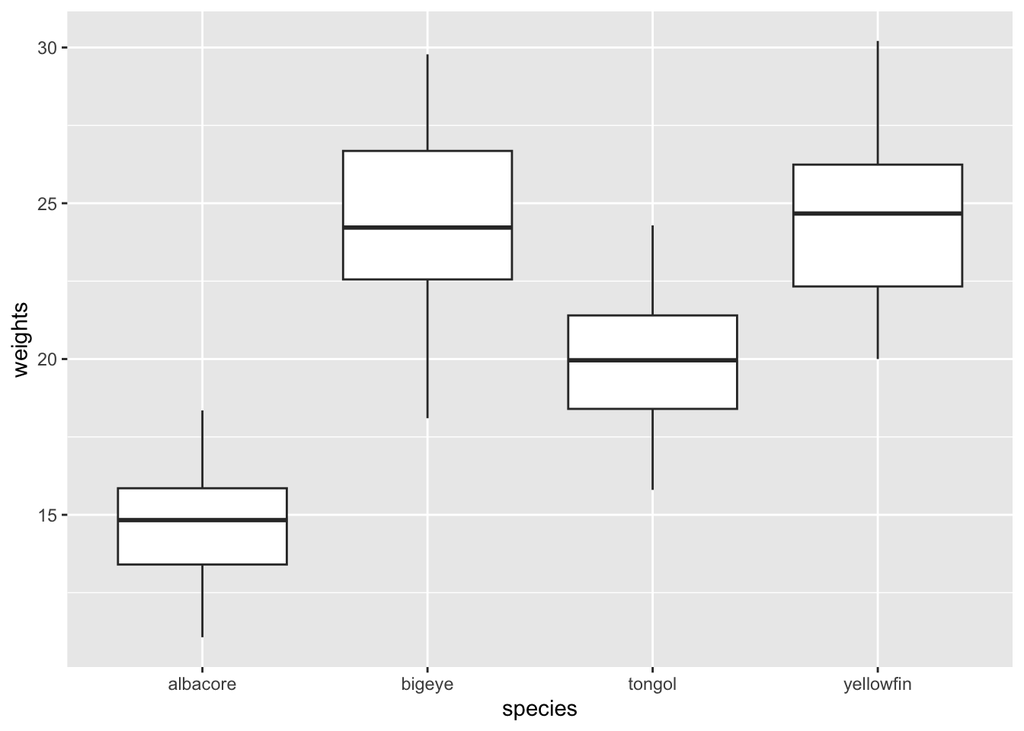

```r
# Place code here.
ggplot(data = fish,
       aes(x = species, y = weights))+
    geom_boxplot()
```

The table can be hard to visualize, so luckily we can pass the `TukeyHSD(aov.model)` into the `plot()` command and get a nice visual for “adjusted confidence intervals” for the difference in means. If the confidence interval below avoids zero, we have evidence for a difference in means for that pair:

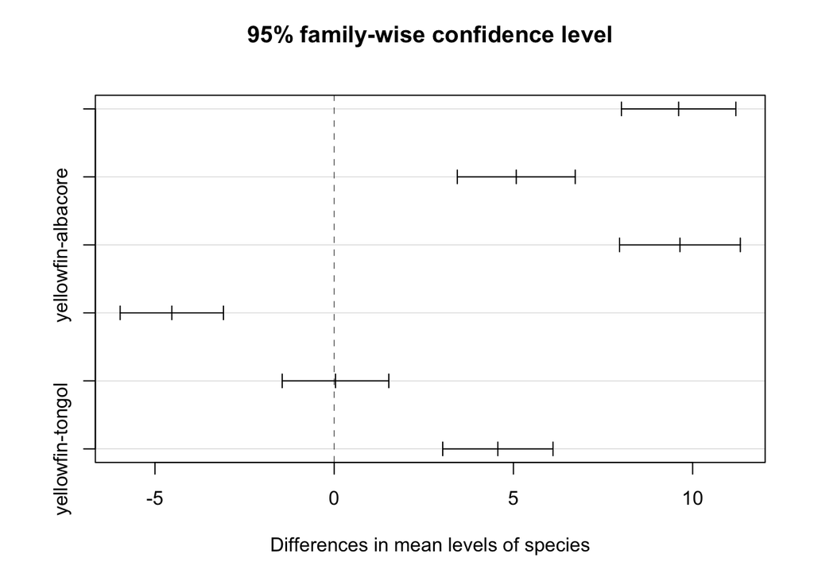

```r
# Place code here.
fish %>%
    aov(weights~species, data = .) %>%
    TukeyHSD() %>% plot()
```

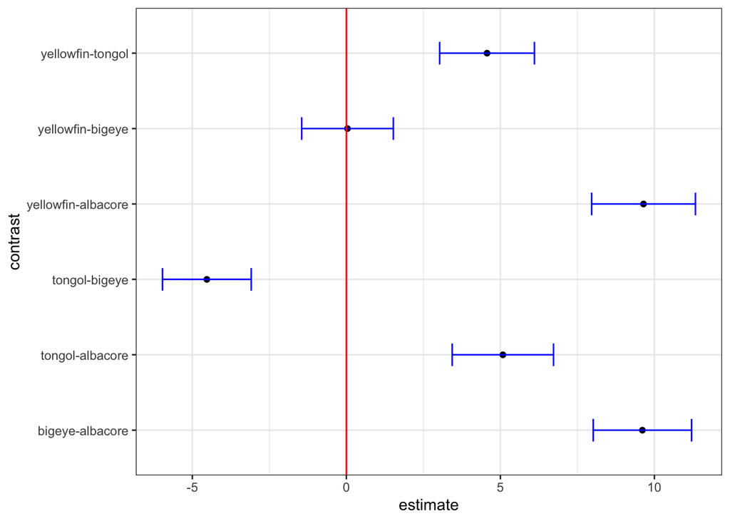

```r
# Here's a reproduction in ggplot where things are a bit easier to control
fish %>%
    aov(weights~species, data = .) %>%
    TukeyHSD() %>% tidy() %>%
    ggplot(data = .,
           aes(y = contrast, x = estimate))+
    geom_point() +
    geom_errorbar(aes(xmin = conf.low, xmax = conf.high),
                  width = .3, color='blue')+
    geom_vline(xintercept = 0, color='red')+ theme_bw()
```

As you can see, not all the labels of the pair-wise comparisons show up nicely in the default plot. I prefer the ggplot() reproduction.

## Recommended Process for Testing Multiple Group Means!

**Note**: Many statisticians suggest when testing for equality among multiple means you do the following:

1. Use ANOVA to see whether there is evidence that at least one mean is different.
   1. *If there is evidence that at least one mean is different*, then run Tukey’s HSD to tease out where the differences lie.
   2. *If we do not have evidence that at least one mean is different*, that concludes the analysis.

I recommend using this work flow as well, since it will have higher statistical *power* in certain cases. (More on power on soon!)